# Marketing Campaigns of Portuguese Bank

KNN classifier

Denaldo Lapi, Francesco Aristei, Samy Chouiti

08 June 2022

Delete all the possible objects of R that could have been left in memory:

```r
rm(list = ls())
```

### 0.0.1 Load data

```r
load("data.RData")
```

We can change values of the target variable int ‘yes’ and ‘no’:

```r
testData$y <- as.factor(ifelse(testData$y=='1',"yes","no"))
trainingData$y <- as.factor(ifelse(trainingData$y=='1',"yes","no"))
```

Let’s visualize the main statistics of the training data

```r
library(dplyr)
library(kableExtra)
library(stats)
trainingData %>%
  summary(.) %>%
  kbl(caption = "Basic statistics. Training data") %>%
  kable_classic(full_width = F, html_font = "Cambria")
```

Basic statistics. Training data

|  | ID | age | balance | duration | campaign | previous | poutcome_failure | poutcome_success | poutcome_unknown | job_admin. | job_blue-collar | job_entrepreneur | job_housemaid | job_management | job_retired | job_self-employed | job_services | job_student | job_technician | job_unemployed | job_unknown | marital_divorced | marital_married | marital_single | education_primary | education_secondary | education_tertiary | education_unknown | default_no | … |
| --- | --- | --- | --- | --- | --- | --- | --- | --- | --- | --- | --- | --- | --- | --- | --- | --- | --- | --- | --- | --- | --- | --- | --- | --- | --- | --- | --- | --- | --- | --- |
|  | Min. : 1 | Min. :19.00 | Min. :-2082 | Min. : 4.0 | Min. : 1.00 | Min. : 0.0000 | Min. :0.0000 | Min. :0.00000 | Min. :0.0000 | Min. :0.0000 | Min. :0.0000 | Min. :0.00000 | Min. :0.00000 | Min. :0.0000 | Min. :0.00000 | Min. :0.00000 | Min. :0.00000 | Min. :0.00000 | Min. :0.0000 | Min. :0.00000 | Min. :0.000000 | Min. :0.0000 | Min. :0.0000 | Min. :0.0000 | Min. :0.000 | Min. :0.000 | Min. :0.0000 | Min. :0.00000 | Min. :0.0000 | … |
|  | 1st Qu.:1149 | 1st Qu.:33.00 | 1st Qu.: 68 | 1st Qu.: 104.0 | 1st Qu.: 1.00 | 1st Qu.: 0.0000 | 1st Qu.:0.0000 | 1st Qu.:0.00000 | 1st Qu.:1.0000 | 1st Qu.:0.0000 | 1st Qu.:0.0000 | 1st Qu.:0.00000 | 1st Qu.:0.00000 | 1st Qu.:0.0000 | 1st Qu.:0.00000 | 1st Qu.:0.00000 | 1st Qu.:0.00000 | 1st Qu.:0.00000 | 1st Qu.:0.0000 | 1st Qu.:0.00000 | 1st Qu.:0.000000 | 1st Qu.:0.0000 | 1st Qu.:0.0000 | 1st Qu.:0.0000 | 1st Qu.:0.000 | 1st Qu.:0.000 | 1st Qu.:0.0000 | 1st Qu.:0.00000 | 1st Qu.:1.0000 | … |
|  | Median :2274 | Median :39.00 | Median : 447 | Median : 185.0 | Median : 2.00 | Median : 0.0000 | Median :0.0000 | Median :0.00000 | Median :1.0000 | Median :0.0000 | Median :0.0000 | Median :0.00000 | Median :0.00000 | Median :0.0000 | Median :0.00000 | Median :0.00000 | Median :0.00000 | Median :0.00000 | Median :0.0000 | Median :0.00000 | Median :0.000000 | Median :0.0000 | Median :1.0000 | Median :0.0000 | Median :0.000 | Median :1.000 | Median :0.0000 | Median :0.00000 | Median :1.0000 | … |
|  | Mean :2271 | Mean :41.06 | Mean : 1406 | Mean : 262.1 | Mean : 2.78 | Mean : 0.5792 | Mean :0.1126 | Mean :0.02913 | Mean :0.8583 | Mean :0.1071 | Mean :0.2097 | Mean :0.03606 | Mean :0.02691 | Mean :0.2141 | Mean :0.05132 | Mean :0.04161 | Mean :0.09126 | Mean :0.01775 | Mean :0.1692 | Mean :0.02802 | Mean :0.006935 | Mean :0.1204 | Mean :0.6144 | Mean :0.2652 | Mean :0.152 | Mean :0.511 | Mean :0.2971 | Mean :0.03994 | Mean :0.9834 | … |
|  | 3rd Qu.:3390 | 3rd Qu.:49.00 | 3rd Qu.: 1480 | 3rd Qu.: 328.0 | 3rd Qu.: 3.00 | 3rd Qu.: 0.0000 | 3rd Qu.:0.0000 | 3rd Qu.:0.00000 | 3rd Qu.:1.0000 | 3rd Qu.:0.0000 | 3rd Qu.:0.0000 | 3rd Qu.:0.00000 | 3rd Qu.:0.00000 | 3rd Qu.:0.0000 | 3rd Qu.:0.00000 | 3rd Qu.:0.00000 | 3rd Qu.:0.00000 | 3rd Qu.:0.00000 | 3rd Qu.:0.0000 | 3rd Qu.:0.00000 | 3rd Qu.:0.000000 | 3rd Qu.:0.0000 | 3rd Qu.:1.0000 | 3rd Qu.:1.0000 | 3rd Qu.:0.000 | 3rd Qu.:1.000 | 3rd Qu.:1.0000 | 3rd Qu.:0.00000 | 3rd Qu.:1.0000 | … |
|  | Max. :4520 | Max. :87.00 | Max. :27359 | Max. :2087.0 | Max. :32.00 | Max. :25.0000 | Max. :1.0000 | Max. :1.00000 | Max. :1.0000 | Max. :1.0000 | Max. :1.0000 | Max. :1.00000 | Max. :1.00000 | Max. :1.0000 | Max. :1.00000 | Max. :1.00000 | Max. :1.00000 | Max. :1.00000 | Max. :1.0000 | Max. :1.00000 | Max. :1.000000 | Max. :1.0000 | Max. :1.0000 | Max. :1.0000 | Max. :1.000 | Max. :1.000 | Max. :1.0000 | Max. :1.00000 | Max. :1.0000 | … |

Test data:

```r
library(dplyr)
library(kableExtra)
library(stats)
testData %>%
  summary(.) %>%
  kbl(caption = "Basic statistics. Test data") %>%
  kable_classic(full_width = F, html_font = "Cambria")
```

Basic statistics. Test data

|  | ID | age | balance | duration | campaign | previous | poutcome_failure | poutcome_success | poutcome_unknown | job_admin. | job_blue-collar | job_entrepreneur | job_housemaid | job_management | job_retired | job_self-employed | job_services | job_student | job_technician | job_unemployed | job_unknown | marital_divorced | marital_married | marital_single | education_primary | education_secondary | education_tertiary | education_unknown | default_no | … |
| --- | --- | --- | --- | --- | --- | --- | --- | --- | --- | --- | --- | --- | --- | --- | --- | --- | --- | --- | --- | --- | --- | --- | --- | --- | --- | --- | --- | --- | --- | --- |
|  | Min. : 6 | Min. :19.00 | Min. : -988.00 | Min. : 5.0 | Min. : 1.000 | Min. : 0.0000 | Min. :0.00000 | Min. :0.00000 | Min. :0.0000 | Min. :0.000 | Min. :0.0000 | Min. :0.00000 | Min. :0.00000 | Min. :0.0000 | Min. :0.00000 | Min. :0.00000 | Min. :0.00000 | Min. :0.00000 | Min. :0.0000 | Min. :0.00000 | Min. :0.00000 | Min. :0.000 | Min. :0.0000 | Min. :0.0000 | Min. :0.0000 | Min. :0.00 | Min. :0.0000 | Min. :0.00000 | Min. :0.0000 | … |
|  | 1st Qu.:1058 | 1st Qu.:34.00 | 1st Qu.: 78.25 | 1st Qu.: 104.0 | 1st Qu.: 1.000 | 1st Qu.: 0.0000 | 1st Qu.:0.00000 | 1st Qu.:0.00000 | 1st Qu.:1.0000 | 1st Qu.:0.000 | 1st Qu.:0.0000 | 1st Qu.:0.00000 | 1st Qu.:0.00000 | 1st Qu.:0.0000 | 1st Qu.:0.00000 | 1st Qu.:0.00000 | 1st Qu.:0.00000 | 1st Qu.:0.00000 | 1st Qu.:0.0000 | 1st Qu.:0.00000 | 1st Qu.:0.00000 | 1st Qu.:0.000 | 1st Qu.:0.0000 | 1st Qu.:0.0000 | 1st Qu.:0.0000 | 1st Qu.:0.00 | 1st Qu.:0.0000 | 1st Qu.:0.00000 | 1st Qu.:1.0000 | … |
|  | Median :2218 | Median :40.00 | Median : 442.50 | Median : 185.0 | Median : 2.000 | Median : 0.0000 | Median :0.00000 | Median :0.00000 | Median :1.0000 | Median :0.000 | Median :0.0000 | Median :0.00000 | Median :0.00000 | Median :0.0000 | Median :0.00000 | Median :0.00000 | Median :0.00000 | Median :0.00000 | Median :0.0000 | Median :0.00000 | Median :0.00000 | Median :0.000 | Median :1.0000 | Median :0.0000 | Median :0.0000 | Median :1.00 | Median :0.0000 | Median :0.00000 | Median :1.0000 | … |
|  | Mean :2210 | Mean :41.54 | Mean : 1378.39 | Mean : 261.9 | Mean : 2.759 | Mean : 0.4035 | Mean :0.09202 | Mean :0.02661 | Mean :0.8814 | Mean :0.102 | Mean :0.2062 | Mean :0.03991 | Mean :0.01663 | Mean :0.2184 | Mean :0.04878 | Mean :0.03548 | Mean :0.09645 | Mean :0.02106 | Mean :0.1741 | Mean :0.02661 | Mean :0.01441 | Mean :0.102 | Mean :0.6341 | Mean :0.2639 | Mean :0.1375 | Mean :0.51 | Mean :0.3049 | Mean :0.04767 | Mean :0.9856 | … |
|  | 3rd Qu.:3375 | 3rd Qu.:48.00 | 3rd Qu.: 1443.25 | 3rd Qu.: 329.0 | 3rd Qu.: 3.000 | 3rd Qu.: 0.0000 | 3rd Qu.:0.00000 | 3rd Qu.:0.00000 | 3rd Qu.:1.0000 | 3rd Qu.:0.000 | 3rd Qu.:0.0000 | 3rd Qu.:0.00000 | 3rd Qu.:0.00000 | 3rd Qu.:0.0000 | 3rd Qu.:0.00000 | 3rd Qu.:0.00000 | 3rd Qu.:0.00000 | 3rd Qu.:0.00000 | 3rd Qu.:0.0000 | 3rd Qu.:0.00000 | 3rd Qu.:0.00000 | 3rd Qu.:0.000 | 3rd Qu.:1.0000 | 3rd Qu.:1.0000 | 3rd Qu.:0.0000 | 3rd Qu.:1.00 | 3rd Qu.:1.0000 | 3rd Qu.:0.00000 | 3rd Qu.:1.0000 | … |
|  | Max. :4521 | Max. :83.00 | Max. :27733.00 | Max. :2029.0 | Max. :28.000 | Max. :24.0000 | Max. :1.00000 | Max. :1.00000 | Max. :1.0000 | Max. :1.000 | Max. :1.0000 | Max. :1.00000 | Max. :1.00000 | Max. :1.0000 | Max. :1.00000 | Max. :1.00000 | Max. :1.00000 | Max. :1.00000 | Max. :1.0000 | Max. :1.00000 | Max. :1.00000 | Max. :1.000 | Max. :1.0000 | Max. :1.0000 | Max. :1.0000 | Max. :1.00 | Max. :1.0000 | Max. :1.00000 | Max. :1.0000 | … |

Variables structure:

```r
str(testData)
```

```
## 'data.frame':    902 obs. of  54 variables:
##  $ ID                   : int  14 51 93 109 111 115 299 300 329 335 ...
##  $ age                  : int  20 45 27 56 21 25 38 32 35 30 ...
##  $ balance              : int  502 844 -195 3391 2488 331 593 759 978 424 ...
##  $ duration             : int  261 1018 391 243 258 170 1484 317 1370 298 ...
##  $ campaign             : int  1 3 1 1 6 4 24 5 3 4 ...
##  $ previous             : int  0 0 0 0 3 0 0 0 3 0 ...
##  $ poutcome_failure     : int  0 0 0 0 0 0 0 0 0 0 ...
##  $ poutcome_success     : int  0 0 0 0 1 0 0 0 1 0 ...
##  $ poutcome_unknown     : int  1 1 1 1 0 1 1 1 0 1 ...
##  $ job_admin.           : int  0 0 0 0 0 0 0 0 0 0 ...
##  $ job_blue-collar      : int  0 1 0 0 0 0 0 1 0 0 ...
##  $ job_entrepreneur     : int  0 0 0 0 0 0 1 0 0 0 ...
##  $ job_housemaid        : int  0 0 0 0 0 0 0 0 0 0 ...
##  $ job_management       : int  0 0 0 0 0 0 0 0 0 1 ...
```

[output cut: 40 more lines]

Levels of the target factor variable:

```r
levels(trainingData$y)
```

```
## [1] "no"  "yes"
```

We can change the levels ordering:

```r
trainingData$y <- relevel(trainingData$y, ref = "yes")
testData$y <- relevel(testData$y, ref = "yes")
levels(trainingData$y)
```

```
## [1] "yes" "no"
```

The positive value is now located on position 1 of the levels.

# 1 KNN classifier

We’ ll use the *caret* package for applying KNN.

At first let’s load the package:

```r
library("caret")
# set seed for repeating the experiments
set.seed(123)
```

We’ll run KNN on the training dataset by applying cross-validation (10-fold) for selecting the optimal value of the K parameter. We can define this in the ‘trainControl’ function:

```r
fitControl <- trainControl(method = "cv",
                           number = 10,
                           ## Estimate class probabilities
                           classProbs = TRUE
)
```

We can now train the model. Since this method is based on distances, it makes sense to normalize and scale the dataset using the ‘preProcess’ parameter of the ‘train’ method:

```r
knn.mod1 <- train(y ~ .,
                 data = trainingData, # train data
                 preProcess = c("center","scale"),
                 method = "knn",
                 trControl = fitControl,
                 tuneGrid = expand.grid(k = seq(1, 70, by = 2))
)
```

Let’s print the resulting model:

```r
knn.mod1
```

```
## k-Nearest Neighbors
##
## 3605 samples
##   53 predictor
##    2 classes: 'yes', 'no'
##
## Pre-processing: centered (53), scaled (53)
## Resampling: Cross-Validated (10 fold)
## Summary of sample sizes: 3245, 3244, 3244, 3245, 3244, 3244, ...
## Resampling results across tuning parameters:
##
##   k   Accuracy   Kappa
##    1  0.8499292   0.1876492872
##    3  0.8793375   0.2019030706
##    5  0.8835018   0.1800146674
```

[output cut: 35 more lines]

We can plot the metrics used for the optimization of K:

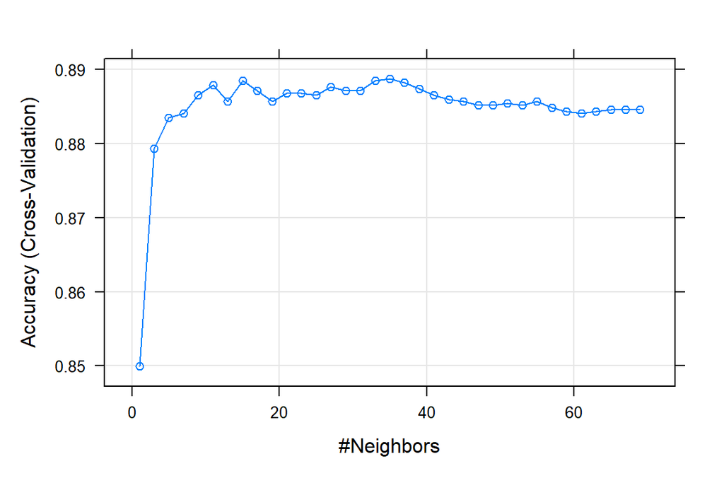

```r
plot(knn.mod1)
```

Best K that optimizes the accuracy:

```r
#Best k-value chosen by KNN
knn.mod1$bestTune
```

|  | k |
| --- | --- |
| 18 | 35 |

Predict test data:

```r
y.knn.pred = predict(knn.mod1, testData)
```

We can show the confusion matrix:

```r
confusionMatrix(y.knn.pred, testData$y, mode = "prec_recall", positive = "yes")
```

```
## Confusion Matrix and Statistics
##
##           Reference
## Prediction yes  no
##        yes   1   0
##        no  103 798
##
##                Accuracy : 0.8858
##                  95% CI : (0.8632, 0.9058)
##     No Information Rate : 0.8847
##     P-Value [Acc > NIR] : 0.4845
##
##                   Kappa : 0.0169
##
##  Mcnemar's Test P-Value : <2e-16
##
##               Precision : 1.000000
##                  Recall : 0.009615
##                      F1 : 0.019048
##              Prevalence : 0.115299
##          Detection Rate : 0.001109
##    Detection Prevalence : 0.001109
##       Balanced Accuracy : 0.504808
##
##        'Positive' Class : yes
##
```

The confusion matrix shows that the model is very good at predicting the negative class, since it is the most represented in the dataset; while it predicts only 1 correct sample in the positive class. Therefore, the accuracy is very high (88.58%) and also the precision, while the recall and the F1-score are very low.

Indeed KNN is run by default by using ‘accuracy’ as an evaluation metric. In our case this may be misleading since the dataset is highly unbalanced, that’s why we now use the *F-score* to tune the value of k. *Caret* contains a summary function called *prSummary* that provides the *F-score*:

```r
fitControl <- trainControl(method = "cv",
                           number = 10,
                           ## Estimate class probabilities
                           classProbs = TRUE,
                           summaryFunction = prSummary
)
```

Let’s retrain the model using the F-score to select k:

```r
knn.mod2 <- train(y ~ .,
                 data = trainingData, # train data
                 preProcess = c("center","scale"),
                 method = "knn",
                 trControl = fitControl,
                 tuneGrid = expand.grid(k = seq(1, 70, by = 2)),
                 metric = "F"
)
```

Print the model:

```r
knn.mod2
```

```
## k-Nearest Neighbors
##
## 3605 samples
##   53 predictor
##    2 classes: 'yes', 'no'
##
## Pre-processing: centered (53), scaled (53)
## Resampling: Cross-Validated (10 fold)
## Summary of sample sizes: 3244, 3244, 3245, 3245, 3244, 3245, ...
## Resampling results across tuning parameters:
##
##   k   AUC        Precision  Recall       F
##    1  0.1522411  0.2931450  0.241463415  0.26411857
##    3  0.2574106  0.4267794  0.175958188  0.24558598
##    5  0.2970418  0.4637746  0.142276423  0.21730715
```

[output cut: 35 more lines]

Plot F-score against k:

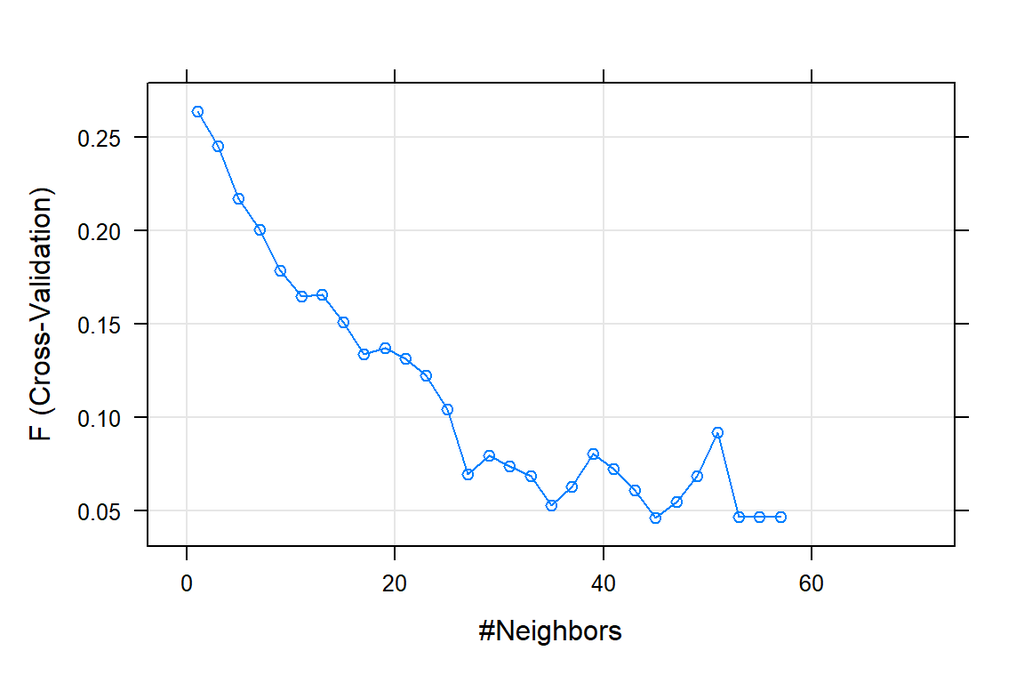

```r
plot(knn.mod2)
```

In this case the optimal chosen k is 1.

Predict test data:

```r
y.knn.pred = predict(knn.mod2, testData)
```

Confusion matrix:

```r
confusionMatrix(y.knn.pred, testData$y, mode = "prec_recall", positive = "yes")
```

```
## Confusion Matrix and Statistics
##
##           Reference
## Prediction yes  no
##        yes  35  45
##        no   69 753
##
##                Accuracy : 0.8736
##                  95% CI : (0.8501, 0.8946)
##     No Information Rate : 0.8847
##     P-Value [Acc > NIR] : 0.86267
##
##                   Kappa : 0.3114
##
##  Mcnemar's Test P-Value : 0.03123
##
##               Precision : 0.43750
##                  Recall : 0.33654
##                      F1 : 0.38043
##              Prevalence : 0.11530
##          Detection Rate : 0.03880
##    Detection Prevalence : 0.08869
##       Balanced Accuracy : 0.64007
##
##        'Positive' Class : yes
##
```

This new model improves quite a lot the recall and the F1 score and also the balanced accuracy, which are the main metrics to look in our problem. However the results are still very poor.

We can also visualize the importance of each variable according to the chosen model:

```r
#Variable importance by SVM model
varImp(knn.mod2)
```

```
## ROC curve variable importance
##
##   only 20 most important variables shown (out of 53)
##
##                       Importance
## duration                 100.000
## previous                  30.411
## pdays_Never contacted     29.592
## poutcome_unknown          24.796
## housing_yes               24.094
## housing_no                24.094
## poutcome_success          22.122
## balance                   21.956
## month_may                 21.670
## campaign                  17.407
## marital_married           14.896
## education_tertiary        14.351
## job_blue-collar           13.634
## pdays_Under 6months       12.908
## loan_yes                  12.196
## loan_no                   12.196
## month_oct                 11.035
## job_retired               10.079
## marital_single             9.757
## education_secondary        8.946
```